# Risk Factor Analysis

## Outcome Variable

**Outcome Variable:** stunted

## Predictor Variables

**Intervention Variable:** perdiar24

**Adjustment Set:**

- arm
- sex
- meducyrs
- hhwealth_quart
- hfoodsec
- hdlvry
- W_birthwt
- W_birthlen
- W_nrooms
- month
- brthmon
- impfloor
- impsan
- safeh20
- delta_meducyrs
- delta_hhwealth_quart
- delta_hfoodsec
- delta_hdlvry
- delta_W_birthwt
- delta_W_birthlen
- delta_W_nrooms
- delta_month
- delta_brthmon
- delta_impfloor
- delta_impsan
- delta_safeh20

## Stratifying Variables

The analysis was stratified on these variable(s):

- agecat
- studyid
- country

## Data Summary

| agecat | studyid | country | perdiar24 | stunted | n_cell | n |
| --- | --- | --- | --- | --- | --- | --- |
| Birth | ki0047075b-MAL-ED | BANGLADESH | 0% | 0 | 16 | 257 |
| Birth | ki0047075b-MAL-ED | BANGLADESH | 0% | 1 | 6 | 257 |
| Birth | ki0047075b-MAL-ED | BANGLADESH | (0%, 5%] | 0 | 126 | 257 |
| Birth | ki0047075b-MAL-ED | BANGLADESH | (0%, 5%] | 1 | 20 | 257 |
| Birth | ki0047075b-MAL-ED | BANGLADESH | >5% | 0 | 68 | 257 |
| Birth | ki0047075b-MAL-ED | BANGLADESH | >5% | 1 | 21 | 257 |
| Birth | ki0047075b-MAL-ED | BRAZIL | 0% | 0 | 97 | 191 |
| Birth | ki0047075b-MAL-ED | BRAZIL | 0% | 1 | 11 | 191 |
| Birth | ki0047075b-MAL-ED | BRAZIL | (0%, 5%] | 0 | 71 | 191 |
| Birth | ki0047075b-MAL-ED | BRAZIL | (0%, 5%] | 1 | 10 | 191 |
| Birth | ki0047075b-MAL-ED | BRAZIL | >5% | 0 | 2 | 191 |
| Birth | ki0047075b-MAL-ED | BRAZIL | >5% | 1 | 0 | 191 |
| Birth | ki0047075b-MAL-ED | INDIA | 0% | 0 | 10 | 206 |
| Birth | ki0047075b-MAL-ED | INDIA | 0% | 1 | 2 | 206 |
| Birth | ki0047075b-MAL-ED | INDIA | (0%, 5%] | 0 | 130 | 206 |
| Birth | ki0047075b-MAL-ED | INDIA | (0%, 5%] | 1 | 26 | 206 |
| Birth | ki0047075b-MAL-ED | INDIA | >5% | 0 | 33 | 206 |
| Birth | ki0047075b-MAL-ED | INDIA | >5% | 1 | 5 | 206 |
| Birth | ki0047075b-MAL-ED | NEPAL | 0% | 0 | 12 | 173 |
| Birth | ki0047075b-MAL-ED | NEPAL | 0% | 1 | 2 | 173 |
| Birth | ki0047075b-MAL-ED | NEPAL | (0%, 5%] | 0 | 96 | 173 |
| Birth | ki0047075b-MAL-ED | NEPAL | (0%, 5%] | 1 | 7 | 173 |
| Birth | ki0047075b-MAL-ED | NEPAL | >5% | 0 | 47 | 173 |
| Birth | ki0047075b-MAL-ED | NEPAL | >5% | 1 | 9 | 173 |
| Birth | ki0047075b-MAL-ED | PERU | 0% | 0 | 25 | 287 |
| Birth | ki0047075b-MAL-ED | PERU | 0% | 1 | 2 | 287 |
| Birth | ki0047075b-MAL-ED | PERU | (0%, 5%] | 0 | 95 | 287 |
| Birth | ki0047075b-MAL-ED | PERU | (0%, 5%] | 1 | 14 | 287 |
| Birth | ki0047075b-MAL-ED | PERU | >5% | 0 | 133 | 287 |
| Birth | ki0047075b-MAL-ED | PERU | >5% | 1 | 18 | 287 |

[output cut: 276 more lines]

The following strata were considered:

- agecat: 24 months, studyid: ki0047075b-MAL-ED, country: BANGLADESH
- agecat: 24 months, studyid: ki0047075b-MAL-ED, country: BRAZIL
- agecat: 24 months, studyid: ki0047075b-MAL-ED, country: INDIA
- agecat: 24 months, studyid: ki0047075b-MAL-ED, country: NEPAL
- agecat: 24 months, studyid: ki0047075b-MAL-ED, country: PERU
- agecat: 24 months, studyid: ki0047075b-MAL-ED, country: SOUTH AFRICA
- agecat: 24 months, studyid: ki0047075b-MAL-ED, country: TANZANIA, UNITED REPUBLIC OF
- agecat: 24 months, studyid: ki1017093-NIH-Birth, country: BANGLADESH
- agecat: 24 months, studyid: ki1017093b-PROVIDE, country: BANGLADESH
- agecat: 24 months, studyid: ki1017093c-NIH-Crypto, country: BANGLADESH
- agecat: 24 months, studyid: ki1114097-CMIN, country: BANGLADESH
- agecat: 24 months, studyid: ki1114097-CMIN, country: GUINEA-BISSAU
- agecat: 24 months, studyid: ki1114097-CMIN, country: PERU
- agecat: 24 months, studyid: ki1114097-CONTENT, country: PERU
- agecat: 24 months, studyid: kiGH5241-JiVitA-4, country: BANGLADESH
- agecat: 6 months, studyid: ki0047075b-MAL-ED, country: BANGLADESH
- agecat: 6 months, studyid: ki0047075b-MAL-ED, country: BRAZIL
- agecat: 6 months, studyid: ki0047075b-MAL-ED, country: INDIA
- agecat: 6 months, studyid: ki0047075b-MAL-ED, country: NEPAL
- agecat: 6 months, studyid: ki0047075b-MAL-ED, country: PERU
- agecat: 6 months, studyid: ki0047075b-MAL-ED, country: SOUTH AFRICA
- agecat: 6 months, studyid: ki0047075b-MAL-ED, country: TANZANIA, UNITED REPUBLIC OF
- agecat: 6 months, studyid: ki1000109-EE, country: PAKISTAN
- agecat: 6 months, studyid: ki1000109-ResPak, country: PAKISTAN
- agecat: 6 months, studyid: ki1000304b-SAS-FoodSuppl, country: INDIA
- agecat: 6 months, studyid: ki1017093-NIH-Birth, country: BANGLADESH
- agecat: 6 months, studyid: ki1017093b-PROVIDE, country: BANGLADESH
- agecat: 6 months, studyid: ki1017093c-NIH-Crypto, country: BANGLADESH
- agecat: 6 months, studyid: ki1112895-Guatemala BSC, country: GUATEMALA
- agecat: 6 months, studyid: ki1114097-CMIN, country: BANGLADESH
- agecat: 6 months, studyid: ki1114097-CMIN, country: BRAZIL
- agecat: 6 months, studyid: ki1114097-CMIN, country: GUINEA-BISSAU
- agecat: 6 months, studyid: ki1114097-CMIN, country: PERU
- agecat: 6 months, studyid: ki1114097-CONTENT, country: PERU
- agecat: 6 months, studyid: kiGH5241-JiVitA-4, country: BANGLADESH
- agecat: Birth, studyid: ki0047075b-MAL-ED, country: BANGLADESH
- agecat: Birth, studyid: ki0047075b-MAL-ED, country: BRAZIL
- agecat: Birth, studyid: ki0047075b-MAL-ED, country: INDIA
- agecat: Birth, studyid: ki0047075b-MAL-ED, country: NEPAL
- agecat: Birth, studyid: ki0047075b-MAL-ED, country: PERU
- agecat: Birth, studyid: ki0047075b-MAL-ED, country: SOUTH AFRICA
- agecat: Birth, studyid: ki0047075b-MAL-ED, country: TANZANIA, UNITED REPUBLIC OF
- agecat: Birth, studyid: ki1000109-EE, country: PAKISTAN
- agecat: Birth, studyid: ki1000109-ResPak, country: PAKISTAN
- agecat: Birth, studyid: ki1017093-NIH-Birth, country: BANGLADESH
- agecat: Birth, studyid: ki1017093c-NIH-Crypto, country: BANGLADESH
- agecat: Birth, studyid: ki1114097-CMIN, country: BANGLADESH
- agecat: Birth, studyid: ki1114097-CMIN, country: BRAZIL
- agecat: Birth, studyid: ki1114097-CMIN, country: PERU
- agecat: Birth, studyid: ki1114097-CONTENT, country: PERU
- agecat: Birth, studyid: kiGH5241-JiVitA-4, country: BANGLADESH

### Dropped Strata

Some strata were dropped due to rare outcomes:

- agecat: Birth, studyid: ki0047075b-MAL-ED, country: BRAZIL
- agecat: Birth, studyid: ki0047075b-MAL-ED, country: INDIA
- agecat: Birth, studyid: ki0047075b-MAL-ED, country: NEPAL
- agecat: Birth, studyid: ki0047075b-MAL-ED, country: PERU
- agecat: Birth, studyid: ki0047075b-MAL-ED, country: SOUTH AFRICA
- agecat: Birth, studyid: ki0047075b-MAL-ED, country: TANZANIA, UNITED REPUBLIC OF
- agecat: Birth, studyid: ki1000109-EE, country: PAKISTAN
- agecat: Birth, studyid: ki1000109-ResPak, country: PAKISTAN
- agecat: Birth, studyid: ki1017093-NIH-Birth, country: BANGLADESH
- agecat: Birth, studyid: ki1017093c-NIH-Crypto, country: BANGLADESH
- agecat: Birth, studyid: ki1114097-CMIN, country: BANGLADESH
- agecat: Birth, studyid: ki1114097-CMIN, country: BRAZIL
- agecat: Birth, studyid: ki1114097-CMIN, country: PERU
- agecat: Birth, studyid: ki1114097-CONTENT, country: PERU
- agecat: 6 months, studyid: ki0047075b-MAL-ED, country: BANGLADESH
- agecat: 6 months, studyid: ki0047075b-MAL-ED, country: BRAZIL
- agecat: 6 months, studyid: ki0047075b-MAL-ED, country: INDIA
- agecat: 6 months, studyid: ki0047075b-MAL-ED, country: NEPAL
- agecat: 6 months, studyid: ki0047075b-MAL-ED, country: PERU
- agecat: 6 months, studyid: ki0047075b-MAL-ED, country: SOUTH AFRICA
- agecat: 6 months, studyid: ki0047075b-MAL-ED, country: TANZANIA, UNITED REPUBLIC OF
- agecat: 6 months, studyid: ki1000109-ResPak, country: PAKISTAN
- agecat: 6 months, studyid: ki1017093b-PROVIDE, country: BANGLADESH
- agecat: 6 months, studyid: ki1114097-CMIN, country: BANGLADESH
- agecat: 6 months, studyid: ki1114097-CMIN, country: BRAZIL
- agecat: 6 months, studyid: ki1114097-CMIN, country: GUINEA-BISSAU
- agecat: 6 months, studyid: ki1114097-CMIN, country: PERU
- agecat: 6 months, studyid: ki1114097-CONTENT, country: PERU
- agecat: 24 months, studyid: ki0047075b-MAL-ED, country: BANGLADESH
- agecat: 24 months, studyid: ki0047075b-MAL-ED, country: BRAZIL
- agecat: 24 months, studyid: ki0047075b-MAL-ED, country: INDIA
- agecat: 24 months, studyid: ki0047075b-MAL-ED, country: NEPAL
- agecat: 24 months, studyid: ki0047075b-MAL-ED, country: PERU
- agecat: 24 months, studyid: ki0047075b-MAL-ED, country: SOUTH AFRICA
- agecat: 24 months, studyid: ki0047075b-MAL-ED, country: TANZANIA, UNITED REPUBLIC OF
- agecat: 24 months, studyid: ki1017093-NIH-Birth, country: BANGLADESH
- agecat: 24 months, studyid: ki1017093b-PROVIDE, country: BANGLADESH
- agecat: 24 months, studyid: ki1114097-CMIN, country: BANGLADESH
- agecat: 24 months, studyid: ki1114097-CONTENT, country: PERU

## Methods Detail

We’re interested in the causal parameters $E[Y_a]$ for all values of $a \in \mathcal{A}$. These parameters represent the mean outcome if, possibly contrary to fact, we intervened to set all units to have $A=a$. Under the randomization and positivity assumptions, these are identified by the statistical parameters $\psi_a=E_W[E_{Y|A,W}(Y|A=a,W)]$. In addition, we’re interested in the mean of $Y$, $E[Y]$ under no intervention (the observed mean). We will estimate these parameters by using SuperLearner to fit the relevant likelihood factors – $E_{Y|A,W}(Y|A=a,W)$ and $p(A=a|W)$, and then updating our likelihood fit using a joint TMLE.

For unadjusted analyses ($W=\{\}$), initial likelihoods were estimated using Lrnr_glm to estimate the simple $E(Y|A)$ and Lrnr_mean to estimate $p(A)$. For adjusted analyses, a small library containing Lrnr_glmnet, Lrnr_xgboost, and Lrnr_mean was used.

Having estimated these parameters, we will then use the delta method to estimate relative risks and attributable risks relative to a prespecified baseline level of $A$.

# Results Detail

## Results Plots

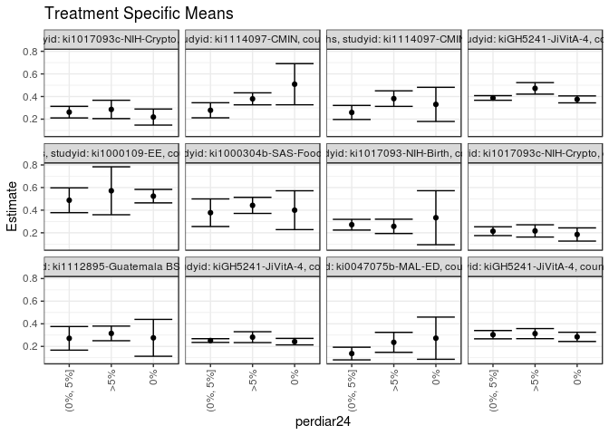

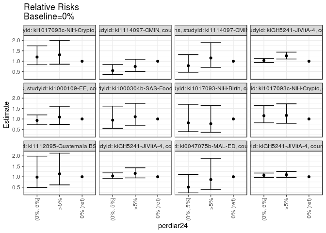

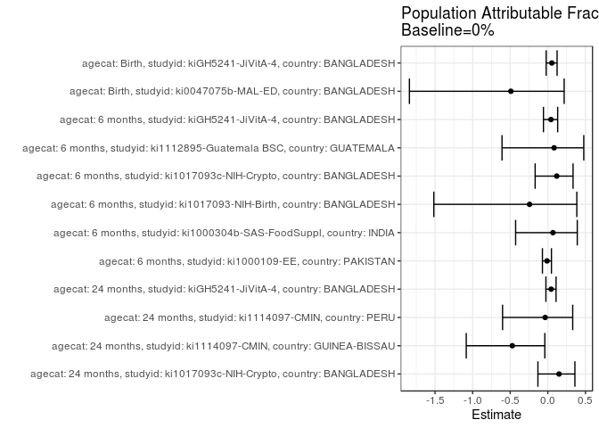

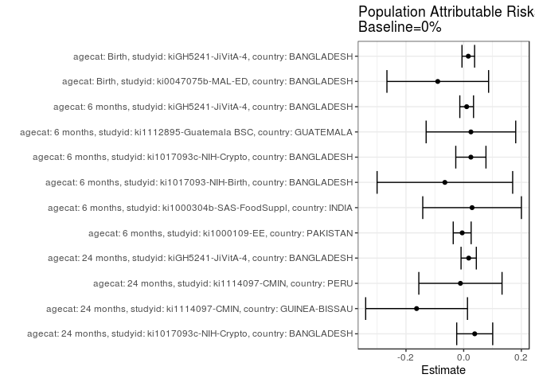

## Results Table

### Parameter: TSM

| agecat | studyid | country | intervention_level | baseline_level | estimate | ci_lower | ci_upper |
| --- | --- | --- | --- | --- | --- | --- | --- |
| Birth | ki0047075b-MAL-ED | BANGLADESH | 0% | NA | 0.2727273 | 0.0862627 | 0.4591918 |
| Birth | ki0047075b-MAL-ED | BANGLADESH | (0%, 5%] | NA | 0.1369863 | 0.0811051 | 0.1928675 |
| Birth | ki0047075b-MAL-ED | BANGLADESH | >5% | NA | 0.2359551 | 0.1475710 | 0.3243391 |
| Birth | kiGH5241-JiVitA-4 | BANGLADESH | 0% | NA | 0.2844441 | 0.2436859 | 0.3252022 |
| Birth | kiGH5241-JiVitA-4 | BANGLADESH | (0%, 5%] | NA | 0.3037209 | 0.2670953 | 0.3403465 |
| Birth | kiGH5241-JiVitA-4 | BANGLADESH | >5% | NA | 0.3131555 | 0.2684949 | 0.3578161 |
| 6 months | ki1000109-EE | PAKISTAN | 0% | NA | 0.5239852 | 0.4644440 | 0.5835265 |
| 6 months | ki1000109-EE | PAKISTAN | (0%, 5%] | NA | 0.4875000 | 0.3778214 | 0.5971786 |
| 6 months | ki1000109-EE | PAKISTAN | >5% | NA | 0.5714286 | 0.3594873 | 0.7833698 |
| 6 months | ki1000304b-SAS-FoodSuppl | INDIA | 0% | NA | 0.3998185 | 0.2279790 | 0.5716579 |
| 6 months | ki1000304b-SAS-FoodSuppl | INDIA | (0%, 5%] | NA | 0.3775865 | 0.2555935 | 0.4995795 |
| 6 months | ki1000304b-SAS-FoodSuppl | INDIA | >5% | NA | 0.4424742 | 0.3713431 | 0.5136053 |
| 6 months | ki1017093-NIH-Birth | BANGLADESH | 0% | NA | 0.3333333 | 0.0945517 | 0.5721150 |
| 6 months | ki1017093-NIH-Birth | BANGLADESH | (0%, 5%] | NA | 0.2713864 | 0.2240064 | 0.3187665 |
| 6 months | ki1017093-NIH-Birth | BANGLADESH | >5% | NA | 0.2568306 | 0.1934736 | 0.3201876 |
| 6 months | ki1017093c-NIH-Crypto | BANGLADESH | 0% | NA | 0.1848440 | 0.1265017 | 0.2431864 |
| 6 months | ki1017093c-NIH-Crypto | BANGLADESH | (0%, 5%] | NA | 0.2140406 | 0.1750982 | 0.2529830 |
| 6 months | ki1017093c-NIH-Crypto | BANGLADESH | >5% | NA | 0.2164937 | 0.1623544 | 0.2706331 |
| 6 months | ki1112895-Guatemala BSC | GUATEMALA | 0% | NA | 0.2758621 | 0.1129200 | 0.4388041 |
| 6 months | ki1112895-Guatemala BSC | GUATEMALA | (0%, 5%] | NA | 0.2714286 | 0.1670791 | 0.3757781 |
| 6 months | ki1112895-Guatemala BSC | GUATEMALA | >5% | NA | 0.3150000 | 0.2505146 | 0.3794854 |
| 6 months | kiGH5241-JiVitA-4 | BANGLADESH | 0% | NA | 0.2421467 | 0.2134498 | 0.2708437 |
| 6 months | kiGH5241-JiVitA-4 | BANGLADESH | (0%, 5%] | NA | 0.2517582 | 0.2352484 | 0.2682679 |
| 6 months | kiGH5241-JiVitA-4 | BANGLADESH | >5% | NA | 0.2818161 | 0.2337392 | 0.3298931 |
| 24 months | ki1017093c-NIH-Crypto | BANGLADESH | 0% | NA | 0.2185503 | 0.1476300 | 0.2894707 |
| 24 months | ki1017093c-NIH-Crypto | BANGLADESH | (0%, 5%] | NA | 0.2620454 | 0.2106900 | 0.3134007 |
| 24 months | ki1017093c-NIH-Crypto | BANGLADESH | >5% | NA | 0.2858730 | 0.2048693 | 0.3668766 |
| 24 months | ki1114097-CMIN | GUINEA-BISSAU | 0% | NA | 0.5090087 | 0.3270085 | 0.6910089 |
| 24 months | ki1114097-CMIN | GUINEA-BISSAU | (0%, 5%] | NA | 0.2784230 | 0.2118021 | 0.3450440 |
| 24 months | ki1114097-CMIN | GUINEA-BISSAU | >5% | NA | 0.3795802 | 0.3263017 | 0.4328587 |
| 24 months | ki1114097-CMIN | PERU | 0% | NA | 0.3304754 | 0.1793527 | 0.4815981 |
| 24 months | ki1114097-CMIN | PERU | (0%, 5%] | NA | 0.2591415 | 0.1969592 | 0.3213238 |
| 24 months | ki1114097-CMIN | PERU | >5% | NA | 0.3817042 | 0.3130508 | 0.4503576 |
| 24 months | kiGH5241-JiVitA-4 | BANGLADESH | 0% | NA | 0.3748623 | 0.3440516 | 0.4056730 |
| 24 months | kiGH5241-JiVitA-4 | BANGLADESH | (0%, 5%] | NA | 0.3874102 | 0.3669276 | 0.4078928 |
| 24 months | kiGH5241-JiVitA-4 | BANGLADESH | >5% | NA | 0.4721528 | 0.4212310 | 0.5230747 |

### Parameter: E(Y)

| agecat | studyid | country | intervention_level | baseline_level | estimate | ci_lower | ci_upper |
| --- | --- | --- | --- | --- | --- | --- | --- |
| Birth | ki0047075b-MAL-ED | BANGLADESH | NA | NA | 0.1828794 | 0.1355257 | 0.2302330 |
| Birth | kiGH5241-JiVitA-4 | BANGLADESH | NA | NA | 0.3004866 | 0.2649179 | 0.3360553 |
| 6 months | ki1000109-EE | PAKISTAN | NA | NA | 0.5188172 | 0.4679751 | 0.5696593 |
| 6 months | ki1000304b-SAS-FoodSuppl | INDIA | NA | NA | 0.4289474 | 0.3791199 | 0.4787748 |
| 6 months | ki1017093-NIH-Birth | BANGLADESH | NA | NA | 0.2681564 | 0.2306532 | 0.3056597 |
| 6 months | ki1017093c-NIH-Crypto | BANGLADESH | NA | NA | 0.2097902 | 0.1799252 | 0.2396552 |
| 6 months | ki1112895-Guatemala BSC | GUATEMALA | NA | NA | 0.3010033 | 0.2489243 | 0.3530824 |
| 6 months | kiGH5241-JiVitA-4 | BANGLADESH | NA | NA | 0.2525357 | 0.2384780 | 0.2665934 |
| 24 months | ki1017093c-NIH-Crypto | BANGLADESH | NA | NA | 0.2568093 | 0.2190047 | 0.2946140 |
| 24 months | ki1114097-CMIN | GUINEA-BISSAU | NA | NA | 0.3457249 | 0.3054989 | 0.3859509 |
| 24 months | ki1114097-CMIN | PERU | NA | NA | 0.3192488 | 0.2749275 | 0.3635701 |
| 24 months | kiGH5241-JiVitA-4 | BANGLADESH | NA | NA | 0.3922559 | 0.3752678 | 0.4092440 |

### Parameter: RR

| agecat | studyid | country | intervention_level | baseline_level | estimate | ci_lower | ci_upper |
| --- | --- | --- | --- | --- | --- | --- | --- |
| Birth | ki0047075b-MAL-ED | BANGLADESH | 0% | 0% | 1.0000000 | 1.0000000 | 1.000000 |
| Birth | ki0047075b-MAL-ED | BANGLADESH | (0%, 5%] | 0% | 0.5022831 | 0.2265603 | 1.113559 |
| Birth | ki0047075b-MAL-ED | BANGLADESH | >5% | 0% | 0.8651685 | 0.3967612 | 1.886567 |
| Birth | kiGH5241-JiVitA-4 | BANGLADESH | 0% | 0% | 1.0000000 | 1.0000000 | 1.000000 |
| Birth | kiGH5241-JiVitA-4 | BANGLADESH | (0%, 5%] | 0% | 1.0677702 | 0.9668121 | 1.179271 |
| Birth | kiGH5241-JiVitA-4 | BANGLADESH | >5% | 0% | 1.1009387 | 0.9692973 | 1.250458 |
| 6 months | ki1000109-EE | PAKISTAN | 0% | 0% | 1.0000000 | 1.0000000 | 1.000000 |
| 6 months | ki1000109-EE | PAKISTAN | (0%, 5%] | 0% | 0.9303697 | 0.7230893 | 1.197069 |
| 6 months | ki1000109-EE | PAKISTAN | >5% | 0% | 1.0905433 | 0.7399020 | 1.607354 |
| 6 months | ki1000304b-SAS-FoodSuppl | INDIA | 0% | 0% | 1.0000000 | 1.0000000 | 1.000000 |
| 6 months | ki1000304b-SAS-FoodSuppl | INDIA | (0%, 5%] | 0% | 0.9443949 | 0.5515128 | 1.617155 |
| 6 months | ki1000304b-SAS-FoodSuppl | INDIA | >5% | 0% | 1.1066877 | 0.6994861 | 1.750939 |
| 6 months | ki1017093-NIH-Birth | BANGLADESH | 0% | 0% | 1.0000000 | 1.0000000 | 1.000000 |
| 6 months | ki1017093-NIH-Birth | BANGLADESH | (0%, 5%] | 0% | 0.8141593 | 0.3894920 | 1.701846 |
| 6 months | ki1017093-NIH-Birth | BANGLADESH | >5% | 0% | 0.7704918 | 0.3611877 | 1.643626 |
| 6 months | ki1017093c-NIH-Crypto | BANGLADESH | 0% | 0% | 1.0000000 | 1.0000000 | 1.000000 |
| 6 months | ki1017093c-NIH-Crypto | BANGLADESH | (0%, 5%] | 0% | 1.1579525 | 0.8157905 | 1.643625 |
| 6 months | ki1017093c-NIH-Crypto | BANGLADESH | >5% | 0% | 1.1712237 | 0.7936214 | 1.728488 |
| 6 months | ki1112895-Guatemala BSC | GUATEMALA | 0% | 0% | 1.0000000 | 1.0000000 | 1.000000 |
| 6 months | ki1112895-Guatemala BSC | GUATEMALA | (0%, 5%] | 0% | 0.9839286 | 0.4862853 | 1.990838 |
| 6 months | ki1112895-Guatemala BSC | GUATEMALA | >5% | 0% | 1.1418750 | 0.6111193 | 2.133591 |
| 6 months | kiGH5241-JiVitA-4 | BANGLADESH | 0% | 0% | 1.0000000 | 1.0000000 | 1.000000 |
| 6 months | kiGH5241-JiVitA-4 | BANGLADESH | (0%, 5%] | 0% | 1.0396928 | 0.9105974 | 1.187090 |
| 6 months | kiGH5241-JiVitA-4 | BANGLADESH | >5% | 0% | 1.1638239 | 0.9456595 | 1.432319 |
| 24 months | ki1017093c-NIH-Crypto | BANGLADESH | 0% | 0% | 1.0000000 | 1.0000000 | 1.000000 |
| 24 months | ki1017093c-NIH-Crypto | BANGLADESH | (0%, 5%] | 0% | 1.1990161 | 0.8280310 | 1.736215 |
| 24 months | ki1017093c-NIH-Crypto | BANGLADESH | >5% | 0% | 1.3080417 | 0.8557586 | 1.999364 |
| 24 months | ki1114097-CMIN | GUINEA-BISSAU | 0% | 0% | 1.0000000 | 1.0000000 | 1.000000 |
| 24 months | ki1114097-CMIN | GUINEA-BISSAU | (0%, 5%] | 0% | 0.5469907 | 0.3562968 | 0.839746 |
| 24 months | ki1114097-CMIN | GUINEA-BISSAU | >5% | 0% | 0.7457243 | 0.5079869 | 1.094723 |
| 24 months | ki1114097-CMIN | PERU | 0% | 0% | 1.0000000 | 1.0000000 | 1.000000 |
| 24 months | ki1114097-CMIN | PERU | (0%, 5%] | 0% | 0.7841475 | 0.4679999 | 1.313862 |
| 24 months | ki1114097-CMIN | PERU | >5% | 0% | 1.1550154 | 0.7067383 | 1.887630 |
| 24 months | kiGH5241-JiVitA-4 | BANGLADESH | 0% | 0% | 1.0000000 | 1.0000000 | 1.000000 |
| 24 months | kiGH5241-JiVitA-4 | BANGLADESH | (0%, 5%] | 0% | 1.0334733 | 0.9386375 | 1.137891 |
| 24 months | kiGH5241-JiVitA-4 | BANGLADESH | >5% | 0% | 1.2595366 | 1.1057664 | 1.434690 |

### Parameter: PAR

| agecat | studyid | country | intervention_level | baseline_level | estimate | ci_lower | ci_upper |
| --- | --- | --- | --- | --- | --- | --- | --- |
| Birth | ki0047075b-MAL-ED | BANGLADESH | 0% | NA | -0.0898479 | -0.2660827 | 0.0863870 |
| Birth | kiGH5241-JiVitA-4 | BANGLADESH | 0% | NA | 0.0160426 | -0.0058156 | 0.0379007 |
| 6 months | ki1000109-EE | PAKISTAN | 0% | NA | -0.0051680 | -0.0362296 | 0.0258935 |
| 6 months | ki1000304b-SAS-FoodSuppl | INDIA | 0% | NA | 0.0291289 | -0.1418792 | 0.2001370 |
| 6 months | ki1017093-NIH-Birth | BANGLADESH | 0% | NA | -0.0651769 | -0.3002043 | 0.1698505 |
| 6 months | ki1017093c-NIH-Crypto | BANGLADESH | 0% | NA | 0.0249462 | -0.0273860 | 0.0772784 |
| 6 months | ki1112895-Guatemala BSC | GUATEMALA | 0% | NA | 0.0251413 | -0.1301396 | 0.1804222 |
| 6 months | kiGH5241-JiVitA-4 | BANGLADESH | 0% | NA | 0.0103890 | -0.0133795 | 0.0341575 |
| 24 months | ki1017093c-NIH-Crypto | BANGLADESH | 0% | NA | 0.0382590 | -0.0241350 | 0.1006530 |
| 24 months | ki1114097-CMIN | GUINEA-BISSAU | 0% | NA | -0.1632838 | -0.3397836 | 0.0132160 |
| 24 months | ki1114097-CMIN | PERU | 0% | NA | -0.0112266 | -0.1554882 | 0.1330350 |
| 24 months | kiGH5241-JiVitA-4 | BANGLADESH | 0% | NA | 0.0173936 | -0.0091033 | 0.0438904 |

### Parameter: PAF

| agecat | studyid | country | intervention_level | baseline_level | estimate | ci_lower | ci_upper |
| --- | --- | --- | --- | --- | --- | --- | --- |
| Birth | ki0047075b-MAL-ED | BANGLADESH | 0% | NA | -0.4912959 | -1.8404579 | 0.2170405 |
| Birth | kiGH5241-JiVitA-4 | BANGLADESH | 0% | NA | 0.0533886 | -0.0221597 | 0.1233531 |
| 6 months | ki1000109-EE | PAKISTAN | 0% | NA | -0.0099612 | -0.0716512 | 0.0481776 |
| 6 months | ki1000304b-SAS-FoodSuppl | INDIA | 0% | NA | 0.0679079 | -0.4281528 | 0.3916647 |
| 6 months | ki1017093-NIH-Birth | BANGLADESH | 0% | NA | -0.2430556 | -1.5158419 | 0.3858171 |
| 6 months | ki1017093c-NIH-Crypto | BANGLADESH | 0% | NA | 0.1189101 | -0.1685657 | 0.3356648 |
| 6 months | ki1112895-Guatemala BSC | GUATEMALA | 0% | NA | 0.0835249 | -0.6090216 | 0.4779892 |
| 6 months | kiGH5241-JiVitA-4 | BANGLADESH | 0% | NA | 0.0411387 | -0.0580157 | 0.1310006 |
| 24 months | ki1017093c-NIH-Crypto | BANGLADESH | 0% | NA | 0.1489782 | -0.1317191 | 0.3600549 |
| 24 months | ki1114097-CMIN | GUINEA-BISSAU | 0% | NA | -0.4722939 | -1.0847544 | -0.0397625 |
| 24 months | ki1114097-CMIN | PERU | 0% | NA | -0.0351657 | -0.6017413 | 0.3309981 |
| 24 months | kiGH5241-JiVitA-4 | BANGLADESH | 0% | NA | 0.0443424 | -0.0255868 | 0.1095034 |